# Model agnostic methods for interpretable machine learning

March 3, 2020

## Material is on my GitHub

- URL
- slides, `R` code, and data hosted here

## Credit where it’s due

(Most) content from *Interpretable Machine Learning: a guide for making black box models explainable* by Christoph Molnar

[figure not shown]

code

## Machine Learning

The IML book focuses supervised learning, which maps features to outcomes

- **Features**: Variables or covariates, the columns in a dataset
- **Instance**: a row in the dataset, all feature values that go with one observation
- **Learner**: the machine learning algorithm, a program used to learn an ML model from data
- **ML Model**: program that maps inputs to predictions, i.e. weights for a linear model or neural network
- **ML Task**: regression, classification, clustering, survival analysis are example tasks

## Importance of interpretability

Interpretability is the degree to which a human can understand the cause of a decision or consistently predict a model’s result, the **how** and **why** a decision was reached.

- Helps us understand when models might fail
- Helps us understand mechanisms behind predictions
- Both crucial for biomedical applications

## Evaluation of interpretability

- **Accuracy**: if the explanation replaces the original model, can it still give good predictions on new data?
- **Fidelity**: how well does the explanation approximate the prediction of the black box model?
- **Consistency**: how much does an explanation differ between models trained for the same task?
- **Stability**: are the explanations for similar instances similar?
- **Comprehensibility**: can people understand the explanation?
- **Certainty**: does it reflect variability in the prediction?
- **Degree of Importance**: if multiple variables go into an explanation, is it clear which are most important?
- **Representativeness**: does it cover predictions from the whole model, or just individual predictions?

## Example data: risk factors for cervical cancer

- binary classification task, indicators and risk factors for cervical cancer
- data from UCI machine learning repository
- 858 subjects
- 16 variables
- `Biopsy` is the outcome variable

```r
table(cervical$Biopsy)
```

```
##
##  Cancer Healthy
##      55     803
```

## Example data: bike share rentals in D.C.

- regression task, goal is to predict how many bikes will be rented depending on the weather and the day
- 731 subjects, 12 variables
- `cnt` is the outcome variable

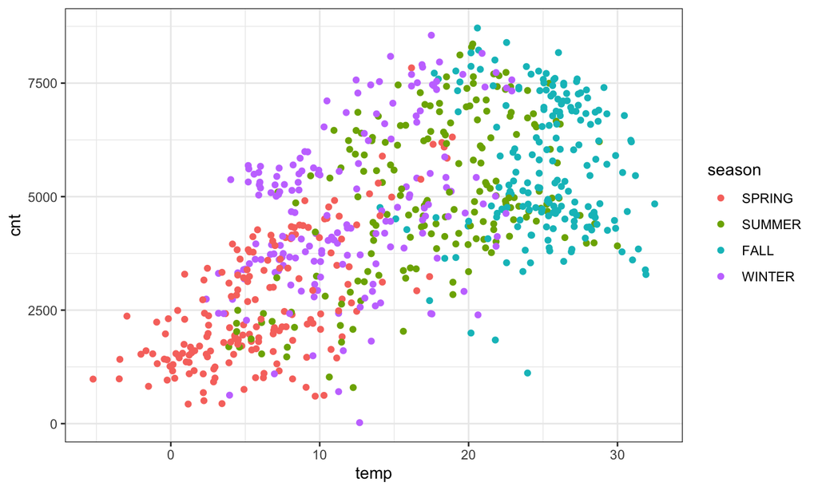

The seasons in this plot don’t make sense.

## Naturally interpretable models

- **Decision trees**:
- **Linear regression**:
- **Logistic regression**:
- **GLMs and GAMs**:
- Have modeling assumptions that are often violated in practice
- Don’t always give great predictions

We’re not gonna focus on these (also, are GAMs that easy to interpret anyway??)

## What are model-agnostic methods?

- Methods that can be used with any ML model, or at least don’t require you to choose one specific model
- These are *post hoc* methods (interpretation methods are applied after the model is trained)

[figure not shown]

## Training a classifier for cervical cancer

I will use the cervical cancer classification task as an example. Code below uses a random forest model to classify patient’s by cervical cancer status.

```r
library(mlr)
library(iml)

task = makeClassifTask(data = cervical,
                       target = "Biopsy")
learner = mlr::makeLearner(cl = 'classif.randomForest',
                           id = 'cervical-rf',
                           predict.type = 'prob')
mod = mlr::train(learner, task)


pred.cervical = iml::Predictor$new(mod, data = cervical, class = "Cancer")
```

## Classification results

- Extremely poor sensitivity
- Need to deal with class imbalance

```r
mod$learner.model
```

```
##
## Call:
##  randomForest(formula = f, data = data, classwt = classwt, cutoff = cutoff)
##                Type of random forest: classification
##                      Number of trees: 500
## No. of variables tried at each split: 3
##
##         OOB estimate of  error rate: 6.53%
## Confusion matrix:
##         Cancer Healthy class.error
## Cancer       0      55  1.00000000
## Healthy      1     802  0.00124533
```

## Partial Dependence Plot (PDP)

- marginal effect one or two features have on the outcome
- shows nature of relationship (linear, quadratic, more complex)
- global method (focuses on overall average)
- clear interpretation: how the average prediction changes when the j-th feature is changed
- easy to implement
- hard to visualize more than 2 features at once
- doesn’t show feature distribution (can over interpret areas with little data)
- **assumes independence** of features, often violated in practice
- alternatives are ICEs and ALEs

## Example PDPs

- for age, probability is low until 40 then increases
- like a PDP for observation-level data

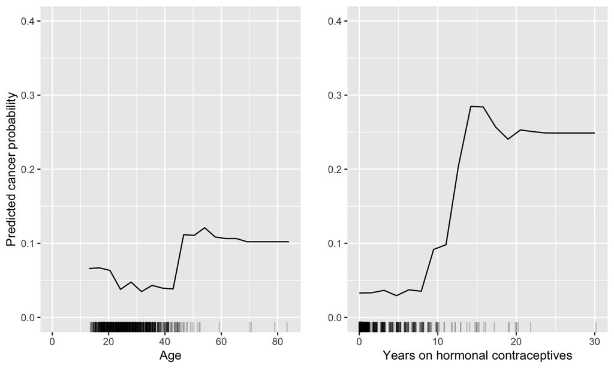

## Individual Conditional Expectation (ICE)

- for each instance, shows how the instance’s prediction changes when a feature changes
- PDP is average of the lines for an ICE plot
- intuitive to understand
- can uncover heterogeneous relationships that PDP cannot
- can only visualize 1 feature at a time
- still **assumes independence** of features

## Example ICEs

- overall cancer probability increases around 50, but less so for women with a high overall probability

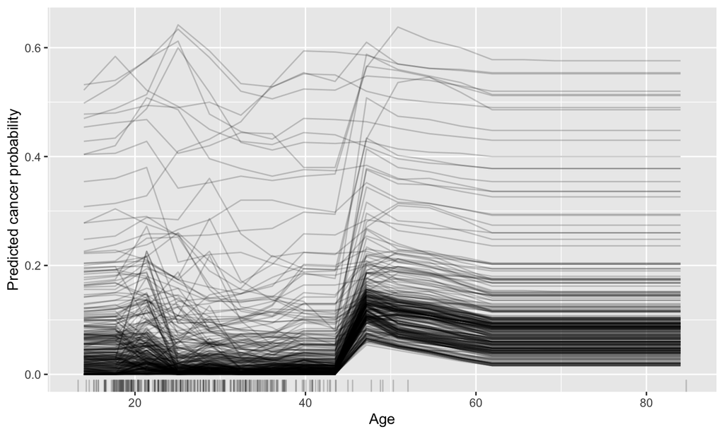

## Accumulated Local Effects (ALE)

- how features influence the prediction of an algorithm on average
- faster and unbiased alternative to PDPs (book has a nice explanation as to why)
  - Change in prediction due to local change in the value of a feature
- interpretation: relative effect of changing a feature value at a particular location
- unbiased (still works when features are correlated)
- easy to implement
- doesn’t work for categorical features without natural ordering
- can be noisy/unstable
- no ICE curve equivalent
- use ALE instead of PDP as rule of thumb

## Example ALES

ALE plots for the effect of age and years with hormonal contraceptives on the predicted probability of cervical cancer

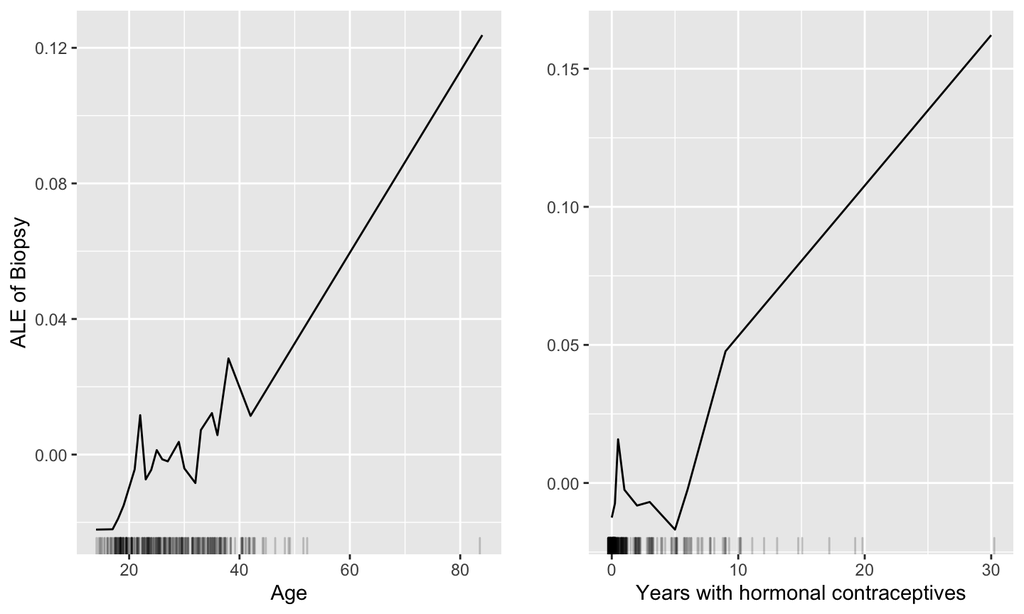

## Feature interaction

- **H-statistic**: measures interaction strength
- often used to measure (1) interaction between two features or (2) interaction between one feature and all others
- meaningful interpretation (share of variance interaction explains)
- comparable across features and models
- can be used for multiple forms of interactions
- takes forever to compute
- value can be greater than 1, which is weird
- not useful for an image classifier
- assumptions can be violated if features correlate strongly

## Example interactions

- Interaction strength for each feature with all other features
- x-axis is amount variance explained by interaction

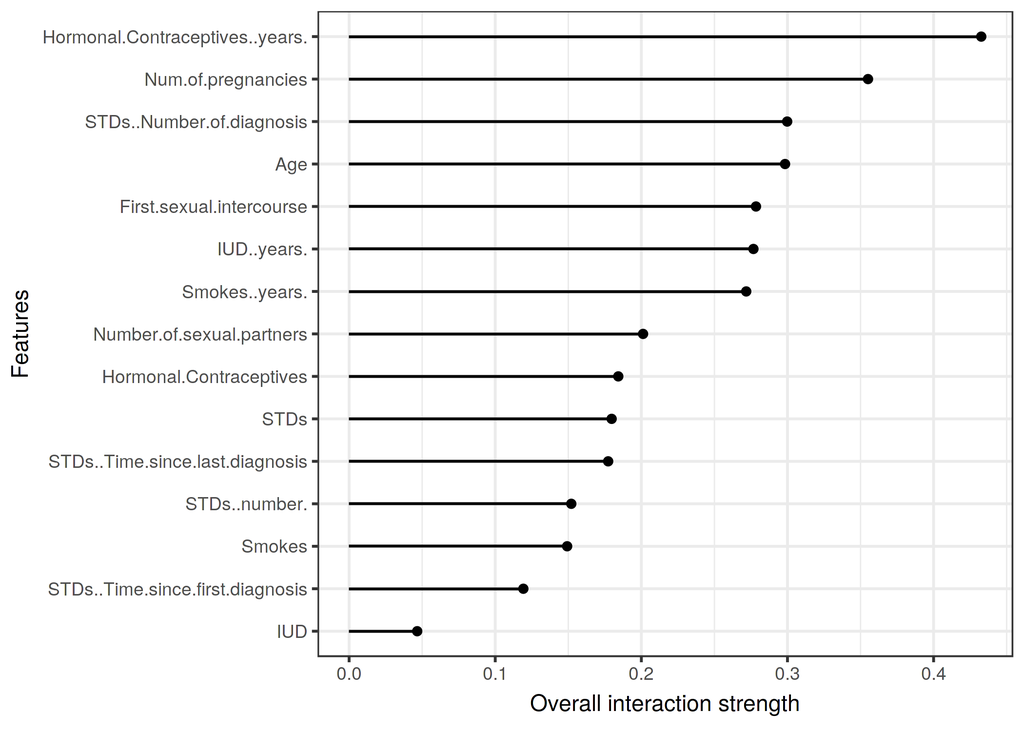

## Example two-way interactions

- Strength of two-way interaction between number of pregnancies and all other variables

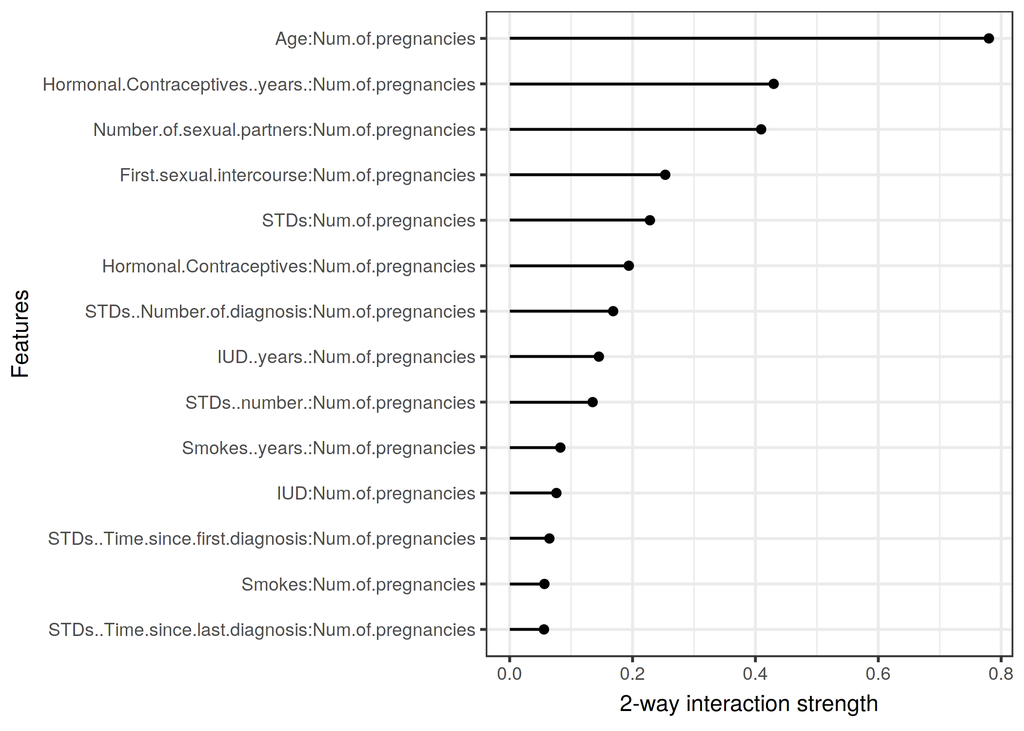

## Permutation feature importance

- measures the increase in the prediction error of the model after we permuted the feature’s values
- originated for random forests (variable importance)
- fit on test or training data? (it depends)
- **interpretation**: increase in the model error when the feature’s information is destroyed
- global insight into model’s behavior
- takes into account interactions with other features
- unclear whether to use training or test data
- need to know true (labeled) outcome value
- permutation adds randomness so results might vary greatly
- correlated features can generate bias (and split importance between correlated features)

## Feature importance plot

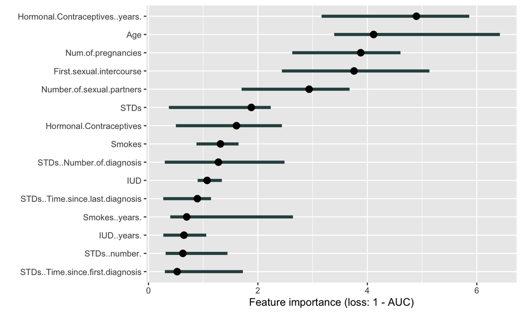

## Global surrogate

This is an interpretable model that is trained to approximate the predictions of the black box model.

- draw conclusions about black box model by interpreting surrogate model
- trains surrogate model using predictions from the black box model as the outcome
- linear models and decision trees are good surrogates
- flexible (lots of surrogate choices) and intuitive
- \(R^2\) measures how good the approximation is
- unclear what \(R^2\) value is good enough
- might be good for some data points but terrible for others

## Global surrogate

Terminal nodes of a surrogate tree for cervical cancer example. The counts in the nodes show the frequency of the black box models classifications in the nodes.

- Doesn’t approximate the RF well here, \(R^2 = 0.19\)

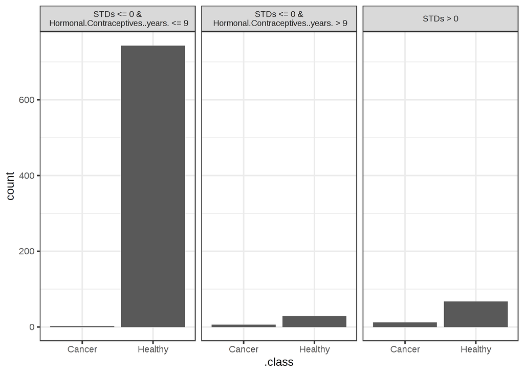

## Local surrogate (LIME)

Local surrogate models are interpretable models that are used to explain individual predictions of black box machine learning models.

- can be used for image classification tasks
- fidelity measure tells us how reliable the surrogate is at explaining predictions in a neighborhood of interest
- unclear how best to define a local neighborhood
- explanations for similar instances can be unstable
- promising, but still in development phase

## Shapley values

Game theory based. The Shapley value is a method for assigning payouts to players depending on their contribution to the total payout. Players cooperate in a coalition and receive a certain profit from this cooperation.

- **game**: the prediction task
- **gain**: actual prediction minus the average prediction for all instances
- **players**: feature values that collaborate to receive the gain
- Shapley value is the average marginal contribution of a feature value across all possible coalitions
- can contrast explanations for different instances
- has solid theory
- very slow
- interpretation: Given the current set of feature values, the contribution of a feature value to the difference between the actual prediction and the mean prediction is the estimated Shapley value
- correlated features are still a problem

## Shapley values

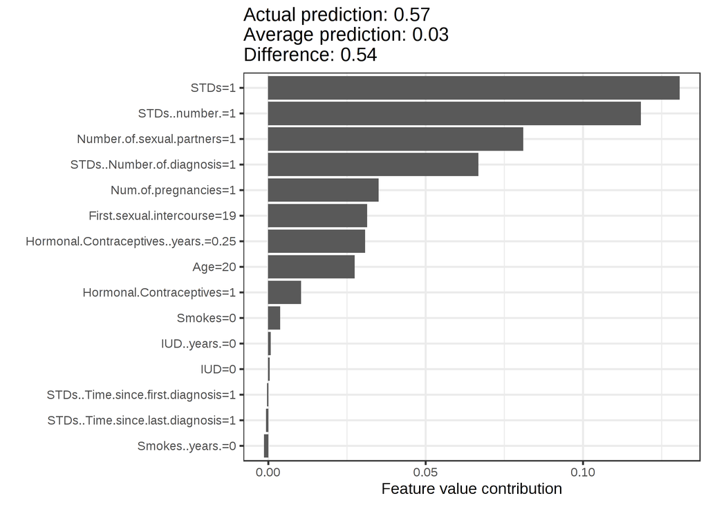